# Risk Factor Analysis

## Outcome Variable

**Outcome Variable:** wasted

## Predictor Variables

**Intervention Variable:** parity

**Adjustment Set:**

- arm
- W_mage
- meducyrs
- feducyrs
- hhwealth_quart
- W_mhtcm
- W_mwtkg
- W_mbmi
- vagbrth
- W_nrooms
- impsan
- delta_W_mage
- delta_meducyrs
- delta_feducyrs
- delta_hhwealth_quart
- delta_W_mhtcm
- delta_W_mwtkg
- delta_W_mbmi
- delta_vagbrth
- delta_W_nrooms
- delta_impsan

## Stratifying Variables

The analysis was stratified on these variable(s):

- agecat
- studyid
- country

## Data Summary

| agecat | studyid | country | parity | wasted | n_cell | n |
| --- | --- | --- | --- | --- | --- | --- |
| Birth | ki1000304b-SAS-CompFeed | INDIA | 1 | 0 | 259 | 1103 |
| Birth | ki1000304b-SAS-CompFeed | INDIA | 1 | 1 | 45 | 1103 |
| Birth | ki1000304b-SAS-CompFeed | INDIA | 2 | 0 | 232 | 1103 |
| Birth | ki1000304b-SAS-CompFeed | INDIA | 2 | 1 | 26 | 1103 |
| Birth | ki1000304b-SAS-CompFeed | INDIA | 3+ | 0 | 494 | 1103 |
| Birth | ki1000304b-SAS-CompFeed | INDIA | 3+ | 1 | 47 | 1103 |
| Birth | ki1017093b-PROVIDE | BANGLADESH | 1 | 0 | 152 | 532 |
| Birth | ki1017093b-PROVIDE | BANGLADESH | 1 | 1 | 50 | 532 |
| Birth | ki1017093b-PROVIDE | BANGLADESH | 2 | 0 | 144 | 532 |
| Birth | ki1017093b-PROVIDE | BANGLADESH | 2 | 1 | 38 | 532 |
| Birth | ki1017093b-PROVIDE | BANGLADESH | 3+ | 0 | 119 | 532 |
| Birth | ki1017093b-PROVIDE | BANGLADESH | 3+ | 1 | 29 | 532 |
| Birth | ki1101329-Keneba | GAMBIA | 1 | 0 | 99 | 1338 |
| Birth | ki1101329-Keneba | GAMBIA | 1 | 1 | 47 | 1338 |
| Birth | ki1101329-Keneba | GAMBIA | 2 | 0 | 110 | 1338 |
| Birth | ki1101329-Keneba | GAMBIA | 2 | 1 | 32 | 1338 |
| Birth | ki1101329-Keneba | GAMBIA | 3+ | 0 | 805 | 1338 |
| Birth | ki1101329-Keneba | GAMBIA | 3+ | 1 | 245 | 1338 |
| Birth | ki1113344-GMS-Nepal | NEPAL | 1 | 0 | 137 | 641 |
| Birth | ki1113344-GMS-Nepal | NEPAL | 1 | 1 | 48 | 641 |
| Birth | ki1113344-GMS-Nepal | NEPAL | 2 | 0 | 132 | 641 |
| Birth | ki1113344-GMS-Nepal | NEPAL | 2 | 1 | 37 | 641 |
| Birth | ki1113344-GMS-Nepal | NEPAL | 3+ | 0 | 240 | 641 |
| Birth | ki1113344-GMS-Nepal | NEPAL | 3+ | 1 | 47 | 641 |
| Birth | ki1126311-ZVITAMBO | ZIMBABWE | 1 | 0 | 4497 | 12916 |
| Birth | ki1126311-ZVITAMBO | ZIMBABWE | 1 | 1 | 1064 | 12916 |
| Birth | ki1126311-ZVITAMBO | ZIMBABWE | 2 | 0 | 3358 | 12916 |
| Birth | ki1126311-ZVITAMBO | ZIMBABWE | 2 | 1 | 524 | 12916 |
| Birth | ki1126311-ZVITAMBO | ZIMBABWE | 3+ | 0 | 3000 | 12916 |
| Birth | ki1126311-ZVITAMBO | ZIMBABWE | 3+ | 1 | 473 | 12916 |

[output cut: 144 more lines]

The following strata were considered:

- agecat: 24 months, studyid: ki1017093b-PROVIDE, country: BANGLADESH
- agecat: 24 months, studyid: ki1066203-TanzaniaChild2, country: TANZANIA, UNITED REPUBLIC OF
- agecat: 24 months, studyid: ki1101329-Keneba, country: GAMBIA
- agecat: 24 months, studyid: ki1113344-GMS-Nepal, country: NEPAL
- agecat: 24 months, studyid: ki1126311-ZVITAMBO, country: ZIMBABWE
- agecat: 24 months, studyid: ki1135781-COHORTS, country: GUATEMALA
- agecat: 24 months, studyid: ki1135781-COHORTS, country: INDIA
- agecat: 24 months, studyid: ki1135781-COHORTS, country: PHILIPPINES
- agecat: 24 months, studyid: kiGH5241-JiVitA-3, country: BANGLADESH
- agecat: 6 months, studyid: ki1000304b-SAS-CompFeed, country: INDIA
- agecat: 6 months, studyid: ki1000304b-SAS-FoodSuppl, country: INDIA
- agecat: 6 months, studyid: ki1017093b-PROVIDE, country: BANGLADESH
- agecat: 6 months, studyid: ki1066203-TanzaniaChild2, country: TANZANIA, UNITED REPUBLIC OF
- agecat: 6 months, studyid: ki1101329-Keneba, country: GAMBIA
- agecat: 6 months, studyid: ki1113344-GMS-Nepal, country: NEPAL
- agecat: 6 months, studyid: ki1126311-ZVITAMBO, country: ZIMBABWE
- agecat: 6 months, studyid: ki1135781-COHORTS, country: GUATEMALA
- agecat: 6 months, studyid: ki1135781-COHORTS, country: INDIA
- agecat: 6 months, studyid: ki1135781-COHORTS, country: PHILIPPINES
- agecat: 6 months, studyid: kiGH5241-JiVitA-3, country: BANGLADESH
- agecat: Birth, studyid: ki1000304b-SAS-CompFeed, country: INDIA
- agecat: Birth, studyid: ki1017093b-PROVIDE, country: BANGLADESH
- agecat: Birth, studyid: ki1101329-Keneba, country: GAMBIA
- agecat: Birth, studyid: ki1113344-GMS-Nepal, country: NEPAL
- agecat: Birth, studyid: ki1126311-ZVITAMBO, country: ZIMBABWE
- agecat: Birth, studyid: ki1135781-COHORTS, country: GUATEMALA
- agecat: Birth, studyid: ki1135781-COHORTS, country: INDIA
- agecat: Birth, studyid: ki1135781-COHORTS, country: PHILIPPINES
- agecat: Birth, studyid: kiGH5241-JiVitA-3, country: BANGLADESH

### Dropped Strata

Some strata were dropped due to rare outcomes:

- agecat: 6 months, studyid: ki1000304b-SAS-FoodSuppl, country: INDIA
- agecat: 6 months, studyid: ki1135781-COHORTS, country: GUATEMALA
- agecat: 24 months, studyid: ki1066203-TanzaniaChild2, country: TANZANIA, UNITED REPUBLIC OF

## Methods Detail

We’re interested in the causal parameters $E[Y_a]$ for all values of $a \in \mathcal{A}$. These parameters represent the mean outcome if, possibly contrary to fact, we intervened to set all units to have $A=a$. Under the randomization and positivity assumptions, these are identified by the statistical parameters $\psi_a=E_W[E_{Y|A,W}(Y|A=a,W)]$. In addition, we’re interested in the mean of $Y$, $E[Y]$ under no intervention (the observed mean). We will estimate these parameters by using SuperLearner to fit the relevant likelihood factors – $E_{Y|A,W}(Y|A=a,W)$ and $p(A=a|W)$, and then updating our likelihood fit using a joint TMLE.

For unadjusted analyses ($W=\{\}$), initial likelihoods were estimated using Lrnr_glm to estimate the simple $E(Y|A)$ and Lrnr_mean to estimate $p(A)$. For adjusted analyses, a small library containing Lrnr_glmnet, Lrnr_xgboost, and Lrnr_mean was used.

Having estimated these parameters, we will then use the delta method to estimate relative risks and attributable risks relative to a prespecified baseline level of $A$.

# Results Detail

## Results Plots

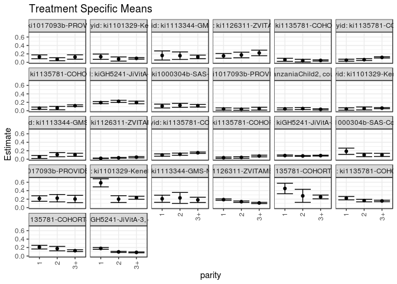

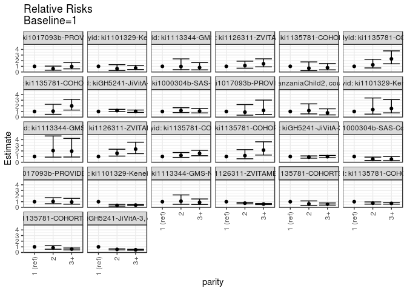

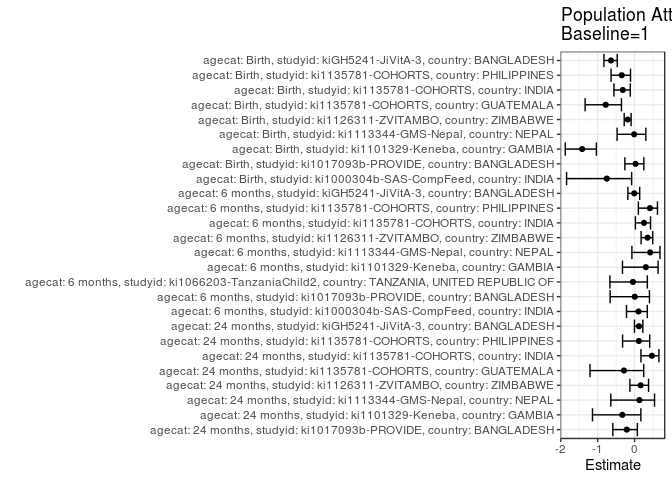

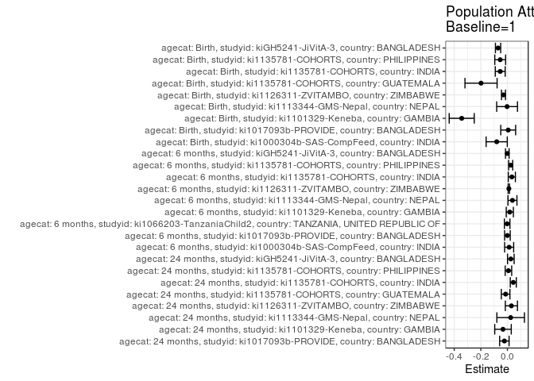

## Results Table

### Parameter: TSM

| agecat | studyid | country | intervention_level | baseline_level | estimate | ci_lower | ci_upper |
| --- | --- | --- | --- | --- | --- | --- | --- |
| Birth | ki1000304b-SAS-CompFeed | INDIA | 1 | NA | 0.1873398 | 0.1132187 | 0.2614610 |
| Birth | ki1000304b-SAS-CompFeed | INDIA | 2 | NA | 0.0999430 | 0.0595513 | 0.1403347 |
| Birth | ki1000304b-SAS-CompFeed | INDIA | 3+ | NA | 0.1005863 | 0.0634188 | 0.1377537 |
| Birth | ki1017093b-PROVIDE | BANGLADESH | 1 | NA | 0.2138301 | 0.1484375 | 0.2792228 |
| Birth | ki1017093b-PROVIDE | BANGLADESH | 2 | NA | 0.2225334 | 0.1355217 | 0.3095451 |
| Birth | ki1017093b-PROVIDE | BANGLADESH | 3+ | NA | 0.2031170 | 0.1170332 | 0.2892009 |
| Birth | ki1101329-Keneba | GAMBIA | 1 | NA | 0.5858887 | 0.4902577 | 0.6815198 |
| Birth | ki1101329-Keneba | GAMBIA | 2 | NA | 0.2003227 | 0.1191545 | 0.2814910 |
| Birth | ki1101329-Keneba | GAMBIA | 3+ | NA | 0.2336218 | 0.1982847 | 0.2689590 |
| Birth | ki1113344-GMS-Nepal | NEPAL | 1 | NA | 0.2083562 | 0.1238137 | 0.2928986 |
| Birth | ki1113344-GMS-Nepal | NEPAL | 2 | NA | 0.2283108 | 0.0988965 | 0.3577252 |
| Birth | ki1113344-GMS-Nepal | NEPAL | 3+ | NA | 0.1818065 | 0.1193810 | 0.2442320 |
| Birth | ki1126311-ZVITAMBO | ZIMBABWE | 1 | NA | 0.1888449 | 0.1723313 | 0.2053585 |
| Birth | ki1126311-ZVITAMBO | ZIMBABWE | 2 | NA | 0.1397482 | 0.1221405 | 0.1573560 |
| Birth | ki1126311-ZVITAMBO | ZIMBABWE | 3+ | NA | 0.1097513 | 0.0948154 | 0.1246872 |
| Birth | ki1135781-COHORTS | GUATEMALA | 1 | NA | 0.4523023 | 0.3278631 | 0.5767415 |
| Birth | ki1135781-COHORTS | GUATEMALA | 2 | NA | 0.2777706 | 0.1234516 | 0.4320896 |
| Birth | ki1135781-COHORTS | GUATEMALA | 3+ | NA | 0.2518393 | 0.2070452 | 0.2966335 |
| Birth | ki1135781-COHORTS | INDIA | 1 | NA | 0.2227633 | 0.1832259 | 0.2623006 |
| Birth | ki1135781-COHORTS | INDIA | 2 | NA | 0.1656780 | 0.1354752 | 0.1958808 |
| Birth | ki1135781-COHORTS | INDIA | 3+ | NA | 0.1565795 | 0.1396239 | 0.1735351 |
| Birth | ki1135781-COHORTS | PHILIPPINES | 1 | NA | 0.2096771 | 0.1660420 | 0.2533123 |
| Birth | ki1135781-COHORTS | PHILIPPINES | 2 | NA | 0.1749167 | 0.1228135 | 0.2270198 |
| Birth | ki1135781-COHORTS | PHILIPPINES | 3+ | NA | 0.1260599 | 0.1038940 | 0.1482258 |
| Birth | kiGH5241-JiVitA-3 | BANGLADESH | 1 | NA | 0.1796085 | 0.1590139 | 0.2002032 |
| Birth | kiGH5241-JiVitA-3 | BANGLADESH | 2 | NA | 0.0974632 | 0.0848029 | 0.1101234 |
| Birth | kiGH5241-JiVitA-3 | BANGLADESH | 3+ | NA | 0.0854579 | 0.0745975 | 0.0963182 |
| 6 months | ki1000304b-SAS-CompFeed | INDIA | 1 | NA | 0.1111601 | 0.0657453 | 0.1565748 |
| 6 months | ki1000304b-SAS-CompFeed | INDIA | 2 | NA | 0.1279740 | 0.0806122 | 0.1753357 |
| 6 months | ki1000304b-SAS-CompFeed | INDIA | 3+ | NA | 0.1187305 | 0.0875485 | 0.1499124 |
| 6 months | ki1017093b-PROVIDE | BANGLADESH | 1 | NA | 0.0412844 | 0.0148531 | 0.0677157 |
| 6 months | ki1017093b-PROVIDE | BANGLADESH | 2 | NA | 0.0360360 | 0.0114985 | 0.0605736 |
| 6 months | ki1017093b-PROVIDE | BANGLADESH | 3+ | NA | 0.0490798 | 0.0158874 | 0.0822721 |
| 6 months | ki1066203-TanzaniaChild2 | TANZANIA, UNITED REPUBLIC OF | 1 | NA | 0.0445183 | 0.0216734 | 0.0673633 |
| 6 months | ki1066203-TanzaniaChild2 | TANZANIA, UNITED REPUBLIC OF | 2 | NA | 0.0513881 | 0.0261870 | 0.0765892 |
| 6 months | ki1066203-TanzaniaChild2 | TANZANIA, UNITED REPUBLIC OF | 3+ | NA | 0.0334726 | 0.0190899 | 0.0478552 |
| 6 months | ki1101329-Keneba | GAMBIA | 1 | NA | 0.0410256 | 0.0131775 | 0.0688738 |
| 6 months | ki1101329-Keneba | GAMBIA | 2 | NA | 0.0548780 | 0.0200120 | 0.0897441 |
| 6 months | ki1101329-Keneba | GAMBIA | 3+ | NA | 0.0625000 | 0.0491515 | 0.0758485 |
| 6 months | ki1113344-GMS-Nepal | NEPAL | 1 | NA | 0.0522876 | 0.0169835 | 0.0875917 |
| 6 months | ki1113344-GMS-Nepal | NEPAL | 2 | NA | 0.1073826 | 0.0576272 | 0.1571379 |
| 6 months | ki1113344-GMS-Nepal | NEPAL | 3+ | NA | 0.1030534 | 0.0662068 | 0.1399000 |
| 6 months | ki1126311-ZVITAMBO | ZIMBABWE | 1 | NA | 0.0201334 | 0.0147028 | 0.0255640 |
| 6 months | ki1126311-ZVITAMBO | ZIMBABWE | 2 | NA | 0.0319403 | 0.0236770 | 0.0402036 |
| 6 months | ki1126311-ZVITAMBO | ZIMBABWE | 3+ | NA | 0.0467385 | 0.0314649 | 0.0620122 |
| 6 months | ki1135781-COHORTS | INDIA | 1 | NA | 0.0976264 | 0.0700560 | 0.1251968 |
| 6 months | ki1135781-COHORTS | INDIA | 2 | NA | 0.1173712 | 0.0913764 | 0.1433660 |
| 6 months | ki1135781-COHORTS | INDIA | 3+ | NA | 0.1521988 | 0.1356768 | 0.1687208 |
| 6 months | ki1135781-COHORTS | PHILIPPINES | 1 | NA | 0.0347277 | 0.0189161 | 0.0505394 |
| 6 months | ki1135781-COHORTS | PHILIPPINES | 2 | NA | 0.0406140 | 0.0219708 | 0.0592572 |
| 6 months | ki1135781-COHORTS | PHILIPPINES | 3+ | NA | 0.0745023 | 0.0553438 | 0.0936609 |
| 6 months | kiGH5241-JiVitA-3 | BANGLADESH | 1 | NA | 0.0853815 | 0.0709553 | 0.0998078 |
| 6 months | kiGH5241-JiVitA-3 | BANGLADESH | 2 | NA | 0.0763892 | 0.0657183 | 0.0870601 |
| 6 months | kiGH5241-JiVitA-3 | BANGLADESH | 3+ | NA | 0.0839863 | 0.0737164 | 0.0942561 |
| 24 months | ki1017093b-PROVIDE | BANGLADESH | 1 | NA | 0.1297953 | 0.0835941 | 0.1759966 |
| 24 months | ki1017093b-PROVIDE | BANGLADESH | 2 | NA | 0.0741803 | 0.0384775 | 0.1098831 |
| 24 months | ki1017093b-PROVIDE | BANGLADESH | 3+ | NA | 0.1255194 | 0.0727350 | 0.1783038 |
| 24 months | ki1101329-Keneba | GAMBIA | 1 | NA | 0.1326312 | 0.0699044 | 0.1953579 |
| 24 months | ki1101329-Keneba | GAMBIA | 2 | NA | 0.0780072 | 0.0287914 | 0.1272230 |
| 24 months | ki1101329-Keneba | GAMBIA | 3+ | NA | 0.0936257 | 0.0759134 | 0.1113380 |
| 24 months | ki1113344-GMS-Nepal | NEPAL | 1 | NA | 0.1622873 | 0.0543710 | 0.2702037 |
| 24 months | ki1113344-GMS-Nepal | NEPAL | 2 | NA | 0.1572328 | 0.0676891 | 0.2467764 |
| 24 months | ki1113344-GMS-Nepal | NEPAL | 3+ | NA | 0.1278721 | 0.0852248 | 0.1705194 |
| 24 months | ki1126311-ZVITAMBO | ZIMBABWE | 1 | NA | 0.1529061 | 0.0969573 | 0.2088549 |
| 24 months | ki1126311-ZVITAMBO | ZIMBABWE | 2 | NA | 0.1737958 | 0.1075351 | 0.2400566 |
| 24 months | ki1126311-ZVITAMBO | ZIMBABWE | 3+ | NA | 0.2220449 | 0.1559205 | 0.2881694 |
| 24 months | ki1135781-COHORTS | GUATEMALA | 1 | NA | 0.0598802 | 0.0238784 | 0.0958821 |
| 24 months | ki1135781-COHORTS | GUATEMALA | 2 | NA | 0.0397351 | 0.0085646 | 0.0709056 |
| 24 months | ki1135781-COHORTS | GUATEMALA | 3+ | NA | 0.0448549 | 0.0301129 | 0.0595968 |
| 24 months | ki1135781-COHORTS | INDIA | 1 | NA | 0.0501665 | 0.0272740 | 0.0730590 |
| 24 months | ki1135781-COHORTS | INDIA | 2 | NA | 0.0635500 | 0.0416701 | 0.0854300 |
| 24 months | ki1135781-COHORTS | INDIA | 3+ | NA | 0.1166091 | 0.1012287 | 0.1319896 |
| 24 months | ki1135781-COHORTS | PHILIPPINES | 1 | NA | 0.0602752 | 0.0343674 | 0.0861831 |
| 24 months | ki1135781-COHORTS | PHILIPPINES | 2 | NA | 0.0637476 | 0.0234769 | 0.1040184 |
| 24 months | ki1135781-COHORTS | PHILIPPINES | 3+ | NA | 0.1191226 | 0.0987936 | 0.1394517 |
| 24 months | kiGH5241-JiVitA-3 | BANGLADESH | 1 | NA | 0.1924448 | 0.1664774 | 0.2184123 |
| 24 months | kiGH5241-JiVitA-3 | BANGLADESH | 2 | NA | 0.2219993 | 0.1963554 | 0.2476432 |
| 24 months | kiGH5241-JiVitA-3 | BANGLADESH | 3+ | NA | 0.1956651 | 0.1643899 | 0.2269404 |

### Parameter: E(Y)

| agecat | studyid | country | intervention_level | baseline_level | estimate | ci_lower | ci_upper |
| --- | --- | --- | --- | --- | --- | --- | --- |
| Birth | ki1000304b-SAS-CompFeed | INDIA | NA | NA | 0.1069810 | 0.0760961 | 0.1378659 |
| Birth | ki1017093b-PROVIDE | BANGLADESH | NA | NA | 0.2199248 | 0.1846953 | 0.2551543 |
| Birth | ki1101329-Keneba | GAMBIA | NA | NA | 0.2421525 | 0.2191900 | 0.2651149 |
| Birth | ki1113344-GMS-Nepal | NEPAL | NA | NA | 0.2059282 | 0.1745993 | 0.2372572 |
| Birth | ki1126311-ZVITAMBO | ZIMBABWE | NA | NA | 0.1595695 | 0.1532538 | 0.1658853 |
| Birth | ki1135781-COHORTS | GUATEMALA | NA | NA | 0.2539683 | 0.2229196 | 0.2850169 |
| Birth | ki1135781-COHORTS | INDIA | NA | NA | 0.1688716 | 0.1570438 | 0.1806994 |
| Birth | ki1135781-COHORTS | PHILIPPINES | NA | NA | 0.1555709 | 0.1423748 | 0.1687670 |
| Birth | kiGH5241-JiVitA-3 | BANGLADESH | NA | NA | 0.1095259 | 0.1044047 | 0.1146471 |
| 6 months | ki1000304b-SAS-CompFeed | INDIA | NA | NA | 0.1244378 | 0.0992652 | 0.1496104 |
| 6 months | ki1017093b-PROVIDE | BANGLADESH | NA | NA | 0.0414594 | 0.0255348 | 0.0573839 |
| 6 months | ki1066203-TanzaniaChild2 | TANZANIA, UNITED REPUBLIC OF | NA | NA | 0.0426279 | 0.0337587 | 0.0514970 |
| 6 months | ki1101329-Keneba | GAMBIA | NA | NA | 0.0591497 | 0.0476693 | 0.0706302 |
| 6 months | ki1113344-GMS-Nepal | NEPAL | NA | NA | 0.0904255 | 0.0667359 | 0.1141152 |
| 6 months | ki1126311-ZVITAMBO | ZIMBABWE | NA | NA | 0.0311618 | 0.0274686 | 0.0348550 |
| 6 months | ki1135781-COHORTS | INDIA | NA | NA | 0.1311552 | 0.1210467 | 0.1412637 |
| 6 months | ki1135781-COHORTS | PHILIPPINES | NA | NA | 0.0594974 | 0.0505830 | 0.0684118 |
| 6 months | kiGH5241-JiVitA-3 | BANGLADESH | NA | NA | 0.0846640 | 0.0798626 | 0.0894653 |
| 24 months | ki1017093b-PROVIDE | BANGLADESH | NA | NA | 0.1070812 | 0.0818727 | 0.1322897 |
| 24 months | ki1101329-Keneba | GAMBIA | NA | NA | 0.0995640 | 0.0837378 | 0.1153901 |
| 24 months | ki1113344-GMS-Nepal | NEPAL | NA | NA | 0.1868583 | 0.1522030 | 0.2215136 |
| 24 months | ki1126311-ZVITAMBO | ZIMBABWE | NA | NA | 0.1828704 | 0.1463759 | 0.2193648 |
| 24 months | ki1135781-COHORTS | GUATEMALA | NA | NA | 0.0464684 | 0.0338852 | 0.0590516 |
| 24 months | ki1135781-COHORTS | INDIA | NA | NA | 0.0945140 | 0.0846121 | 0.1044160 |
| 24 months | ki1135781-COHORTS | PHILIPPINES | NA | NA | 0.0681911 | 0.0582056 | 0.0781766 |
| 24 months | kiGH5241-JiVitA-3 | BANGLADESH | NA | NA | 0.2182959 | 0.2084450 | 0.2281469 |

### Parameter: RR

| agecat | studyid | country | intervention_level | baseline_level | estimate | ci_lower | ci_upper |
| --- | --- | --- | --- | --- | --- | --- | --- |
| Birth | ki1000304b-SAS-CompFeed | INDIA | 1 | 1 | 1.0000000 | 1.0000000 | 1.0000000 |
| Birth | ki1000304b-SAS-CompFeed | INDIA | 2 | 1 | 0.5334851 | 0.3129945 | 0.9093016 |
| Birth | ki1000304b-SAS-CompFeed | INDIA | 3+ | 1 | 0.5369189 | 0.2829364 | 1.0188929 |
| Birth | ki1017093b-PROVIDE | BANGLADESH | 1 | 1 | 1.0000000 | 1.0000000 | 1.0000000 |
| Birth | ki1017093b-PROVIDE | BANGLADESH | 2 | 1 | 1.0407017 | 0.6339731 | 1.7083690 |
| Birth | ki1017093b-PROVIDE | BANGLADESH | 3+ | 1 | 0.9498990 | 0.5644368 | 1.5985991 |
| Birth | ki1101329-Keneba | GAMBIA | 1 | 1 | 1.0000000 | 1.0000000 | 1.0000000 |
| Birth | ki1101329-Keneba | GAMBIA | 2 | 1 | 0.3419126 | 0.2208860 | 0.5292512 |
| Birth | ki1101329-Keneba | GAMBIA | 3+ | 1 | 0.3987478 | 0.3191419 | 0.4982103 |
| Birth | ki1113344-GMS-Nepal | NEPAL | 1 | 1 | 1.0000000 | 1.0000000 | 1.0000000 |
| Birth | ki1113344-GMS-Nepal | NEPAL | 2 | 1 | 1.0957720 | 0.5454642 | 2.2012742 |
| Birth | ki1113344-GMS-Nepal | NEPAL | 3+ | 1 | 0.8725756 | 0.5129705 | 1.4842729 |
| Birth | ki1126311-ZVITAMBO | ZIMBABWE | 1 | 1 | 1.0000000 | 1.0000000 | 1.0000000 |
| Birth | ki1126311-ZVITAMBO | ZIMBABWE | 2 | 1 | 0.7400160 | 0.6347885 | 0.8626869 |
| Birth | ki1126311-ZVITAMBO | ZIMBABWE | 3+ | 1 | 0.5811715 | 0.4943641 | 0.6832219 |
| Birth | ki1135781-COHORTS | GUATEMALA | 1 | 1 | 1.0000000 | 1.0000000 | 1.0000000 |
| Birth | ki1135781-COHORTS | GUATEMALA | 2 | 1 | 0.6141259 | 0.3304085 | 1.1414678 |
| Birth | ki1135781-COHORTS | GUATEMALA | 3+ | 1 | 0.5567943 | 0.4013131 | 0.7725137 |
| Birth | ki1135781-COHORTS | INDIA | 1 | 1 | 1.0000000 | 1.0000000 | 1.0000000 |
| Birth | ki1135781-COHORTS | INDIA | 2 | 1 | 0.7437402 | 0.5766437 | 0.9592570 |
| Birth | ki1135781-COHORTS | INDIA | 3+ | 1 | 0.7028965 | 0.5709644 | 0.8653140 |
| Birth | ki1135781-COHORTS | PHILIPPINES | 1 | 1 | 1.0000000 | 1.0000000 | 1.0000000 |
| Birth | ki1135781-COHORTS | PHILIPPINES | 2 | 1 | 0.8342192 | 0.5799860 | 1.1998940 |
| Birth | ki1135781-COHORTS | PHILIPPINES | 3+ | 1 | 0.6012094 | 0.4578172 | 0.7895133 |
| Birth | kiGH5241-JiVitA-3 | BANGLADESH | 1 | 1 | 1.0000000 | 1.0000000 | 1.0000000 |
| Birth | kiGH5241-JiVitA-3 | BANGLADESH | 2 | 1 | 0.5426422 | 0.4585732 | 0.6421235 |
| Birth | kiGH5241-JiVitA-3 | BANGLADESH | 3+ | 1 | 0.4758007 | 0.4004198 | 0.5653724 |
| 6 months | ki1000304b-SAS-CompFeed | INDIA | 1 | 1 | 1.0000000 | 1.0000000 | 1.0000000 |
| 6 months | ki1000304b-SAS-CompFeed | INDIA | 2 | 1 | 1.1512584 | 0.7966466 | 1.6637188 |
| 6 months | ki1000304b-SAS-CompFeed | INDIA | 3+ | 1 | 1.0681036 | 0.7457601 | 1.5297752 |
| 6 months | ki1017093b-PROVIDE | BANGLADESH | 1 | 1 | 1.0000000 | 1.0000000 | 1.0000000 |
| 6 months | ki1017093b-PROVIDE | BANGLADESH | 2 | 1 | 0.8728729 | 0.3428041 | 2.2225725 |
| 6 months | ki1017093b-PROVIDE | BANGLADESH | 3+ | 1 | 1.1888207 | 0.4684591 | 3.0169011 |
| 6 months | ki1066203-TanzaniaChild2 | TANZANIA, UNITED REPUBLIC OF | 1 | 1 | 1.0000000 | 1.0000000 | 1.0000000 |
| 6 months | ki1066203-TanzaniaChild2 | TANZANIA, UNITED REPUBLIC OF | 2 | 1 | 1.1543134 | 0.5679563 | 2.3460243 |
| 6 months | ki1066203-TanzaniaChild2 | TANZANIA, UNITED REPUBLIC OF | 3+ | 1 | 0.7518823 | 0.3849838 | 1.4684437 |
| 6 months | ki1101329-Keneba | GAMBIA | 1 | 1 | 1.0000000 | 1.0000000 | 1.0000000 |
| 6 months | ki1101329-Keneba | GAMBIA | 2 | 1 | 1.3376523 | 0.5279118 | 3.3894177 |
| 6 months | ki1101329-Keneba | GAMBIA | 3+ | 1 | 1.5234373 | 0.7477881 | 3.1036350 |
| 6 months | ki1113344-GMS-Nepal | NEPAL | 1 | 1 | 1.0000000 | 1.0000000 | 1.0000000 |
| 6 months | ki1113344-GMS-Nepal | NEPAL | 2 | 1 | 2.0536913 | 0.9055194 | 4.6577113 |
| 6 months | ki1113344-GMS-Nepal | NEPAL | 3+ | 1 | 1.9708969 | 0.9180260 | 4.2312905 |
| 6 months | ki1126311-ZVITAMBO | ZIMBABWE | 1 | 1 | 1.0000000 | 1.0000000 | 1.0000000 |
| 6 months | ki1126311-ZVITAMBO | ZIMBABWE | 2 | 1 | 1.5864345 | 1.0917548 | 2.3052559 |
| 6 months | ki1126311-ZVITAMBO | ZIMBABWE | 3+ | 1 | 2.3214455 | 1.5196882 | 3.5461940 |
| 6 months | ki1135781-COHORTS | INDIA | 1 | 1 | 1.0000000 | 1.0000000 | 1.0000000 |
| 6 months | ki1135781-COHORTS | INDIA | 2 | 1 | 1.2022481 | 0.8396505 | 1.7214311 |
| 6 months | ki1135781-COHORTS | INDIA | 3+ | 1 | 1.5589916 | 1.1519407 | 2.1098784 |
| 6 months | ki1135781-COHORTS | PHILIPPINES | 1 | 1 | 1.0000000 | 1.0000000 | 1.0000000 |
| 6 months | ki1135781-COHORTS | PHILIPPINES | 2 | 1 | 1.1694982 | 0.6129690 | 2.2313136 |
| 6 months | ki1135781-COHORTS | PHILIPPINES | 3+ | 1 | 2.1453270 | 1.2717547 | 3.6189590 |
| 6 months | kiGH5241-JiVitA-3 | BANGLADESH | 1 | 1 | 1.0000000 | 1.0000000 | 1.0000000 |
| 6 months | kiGH5241-JiVitA-3 | BANGLADESH | 2 | 1 | 0.8946809 | 0.7171020 | 1.1162345 |
| 6 months | kiGH5241-JiVitA-3 | BANGLADESH | 3+ | 1 | 0.9836582 | 0.8029726 | 1.2050019 |
| 24 months | ki1017093b-PROVIDE | BANGLADESH | 1 | 1 | 1.0000000 | 1.0000000 | 1.0000000 |
| 24 months | ki1017093b-PROVIDE | BANGLADESH | 2 | 1 | 0.5715175 | 0.3139183 | 1.0405006 |
| 24 months | ki1017093b-PROVIDE | BANGLADESH | 3+ | 1 | 0.9670563 | 0.5574317 | 1.6776905 |
| 24 months | ki1101329-Keneba | GAMBIA | 1 | 1 | 1.0000000 | 1.0000000 | 1.0000000 |
| 24 months | ki1101329-Keneba | GAMBIA | 2 | 1 | 0.5881513 | 0.2672393 | 1.2944274 |
| 24 months | ki1101329-Keneba | GAMBIA | 3+ | 1 | 0.7059103 | 0.4242412 | 1.1745898 |
| 24 months | ki1113344-GMS-Nepal | NEPAL | 1 | 1 | 1.0000000 | 1.0000000 | 1.0000000 |
| 24 months | ki1113344-GMS-Nepal | NEPAL | 2 | 1 | 0.9688542 | 0.4044564 | 2.3208396 |
| 24 months | ki1113344-GMS-Nepal | NEPAL | 3+ | 1 | 0.7879365 | 0.3736227 | 1.6616868 |
| 24 months | ki1126311-ZVITAMBO | ZIMBABWE | 1 | 1 | 1.0000000 | 1.0000000 | 1.0000000 |
| 24 months | ki1126311-ZVITAMBO | ZIMBABWE | 2 | 1 | 1.1366177 | 0.6728236 | 1.9201165 |
| 24 months | ki1126311-ZVITAMBO | ZIMBABWE | 3+ | 1 | 1.4521650 | 0.9058945 | 2.3278465 |
| 24 months | ki1135781-COHORTS | GUATEMALA | 1 | 1 | 1.0000000 | 1.0000000 | 1.0000000 |
| 24 months | ki1135781-COHORTS | GUATEMALA | 2 | 1 | 0.6635762 | 0.2469743 | 1.7829113 |
| 24 months | ki1135781-COHORTS | GUATEMALA | 3+ | 1 | 0.7490765 | 0.3775276 | 1.4862905 |
| 24 months | ki1135781-COHORTS | INDIA | 1 | 1 | 1.0000000 | 1.0000000 | 1.0000000 |
| 24 months | ki1135781-COHORTS | INDIA | 2 | 1 | 1.2667828 | 0.7154036 | 2.2431235 |
| 24 months | ki1135781-COHORTS | INDIA | 3+ | 1 | 2.3244435 | 1.4455817 | 3.7376218 |
| 24 months | ki1135781-COHORTS | PHILIPPINES | 1 | 1 | 1.0000000 | 1.0000000 | 1.0000000 |
| 24 months | ki1135781-COHORTS | PHILIPPINES | 2 | 1 | 1.0576087 | 0.4925825 | 2.2707591 |
| 24 months | ki1135781-COHORTS | PHILIPPINES | 3+ | 1 | 1.9763112 | 1.2443661 | 3.1387916 |
| 24 months | kiGH5241-JiVitA-3 | BANGLADESH | 1 | 1 | 1.0000000 | 1.0000000 | 1.0000000 |
| 24 months | kiGH5241-JiVitA-3 | BANGLADESH | 2 | 1 | 1.1535737 | 0.9640870 | 1.3803030 |
| 24 months | kiGH5241-JiVitA-3 | BANGLADESH | 3+ | 1 | 1.0167338 | 0.8238825 | 1.2547271 |

### Parameter: PAR

| agecat | studyid | country | intervention_level | baseline_level | estimate | ci_lower | ci_upper |
| --- | --- | --- | --- | --- | --- | --- | --- |
| Birth | ki1000304b-SAS-CompFeed | INDIA | 1 | NA | -0.0803588 | -0.1599846 | -0.0007331 |
| Birth | ki1017093b-PROVIDE | BANGLADESH | 1 | NA | 0.0060947 | -0.0498136 | 0.0620029 |
| Birth | ki1101329-Keneba | GAMBIA | 1 | NA | -0.3437363 | -0.4380002 | -0.2494724 |
| Birth | ki1113344-GMS-Nepal | NEPAL | 1 | NA | -0.0024279 | -0.0807258 | 0.0758700 |
| Birth | ki1126311-ZVITAMBO | ZIMBABWE | 1 | NA | -0.0292754 | -0.0442221 | -0.0143286 |
| Birth | ki1135781-COHORTS | GUATEMALA | 1 | NA | -0.1983340 | -0.3191895 | -0.0774786 |
| Birth | ki1135781-COHORTS | INDIA | 1 | NA | -0.0538917 | -0.0911093 | -0.0166740 |
| Birth | ki1135781-COHORTS | PHILIPPINES | 1 | NA | -0.0541062 | -0.0948956 | -0.0133169 |
| Birth | kiGH5241-JiVitA-3 | BANGLADESH | 1 | NA | -0.0700826 | -0.0897680 | -0.0503972 |
| 6 months | ki1000304b-SAS-CompFeed | INDIA | 1 | NA | 0.0132777 | -0.0206639 | 0.0472194 |
| 6 months | ki1017093b-PROVIDE | BANGLADESH | 1 | NA | 0.0001750 | -0.0209691 | 0.0213190 |
| 6 months | ki1066203-TanzaniaChild2 | TANZANIA, UNITED REPUBLIC OF | 1 | NA | -0.0018905 | -0.0227527 | 0.0189718 |
| 6 months | ki1101329-Keneba | GAMBIA | 1 | NA | 0.0181241 | -0.0087267 | 0.0449749 |
| 6 months | ki1113344-GMS-Nepal | NEPAL | 1 | NA | 0.0381380 | 0.0045024 | 0.0717735 |
| 6 months | ki1126311-ZVITAMBO | ZIMBABWE | 1 | NA | 0.0110284 | 0.0059931 | 0.0160638 |
| 6 months | ki1135781-COHORTS | INDIA | 1 | NA | 0.0335287 | 0.0068724 | 0.0601851 |
| 6 months | ki1135781-COHORTS | PHILIPPINES | 1 | NA | 0.0247697 | 0.0093807 | 0.0401586 |
| 6 months | kiGH5241-JiVitA-3 | BANGLADESH | 1 | NA | -0.0007176 | -0.0142204 | 0.0127852 |
| 24 months | ki1017093b-PROVIDE | BANGLADESH | 1 | NA | -0.0227142 | -0.0581858 | 0.0127575 |
| 24 months | ki1101329-Keneba | GAMBIA | 1 | NA | -0.0330672 | -0.0952578 | 0.0291234 |
| 24 months | ki1113344-GMS-Nepal | NEPAL | 1 | NA | 0.0245710 | -0.0790922 | 0.1282342 |
| 24 months | ki1126311-ZVITAMBO | ZIMBABWE | 1 | NA | 0.0299642 | -0.0157011 | 0.0756295 |
| 24 months | ki1135781-COHORTS | GUATEMALA | 1 | NA | -0.0134118 | -0.0458485 | 0.0190249 |
| 24 months | ki1135781-COHORTS | INDIA | 1 | NA | 0.0443475 | 0.0216308 | 0.0670642 |
| 24 months | ki1135781-COHORTS | PHILIPPINES | 1 | NA | 0.0079159 | -0.0165031 | 0.0323349 |
| 24 months | kiGH5241-JiVitA-3 | BANGLADESH | 1 | NA | 0.0258511 | 0.0010623 | 0.0506400 |

### Parameter: PAF

| agecat | studyid | country | intervention_level | baseline_level | estimate | ci_lower | ci_upper |
| --- | --- | --- | --- | --- | --- | --- | --- |
| Birth | ki1000304b-SAS-CompFeed | INDIA | 1 | NA | -0.7511509 | -1.8421001 | -0.0789660 |
| Birth | ki1017093b-PROVIDE | BANGLADESH | 1 | NA | 0.0277125 | -0.2627501 | 0.2513618 |
| Birth | ki1101329-Keneba | GAMBIA | 1 | NA | -1.4195035 | -1.8777839 | -1.0342032 |
| Birth | ki1113344-GMS-Nepal | NEPAL | 1 | NA | -0.0117901 | -0.4732950 | 0.3051499 |
| Birth | ki1126311-ZVITAMBO | ZIMBABWE | 1 | NA | -0.1834646 | -0.2808536 | -0.0934806 |
| Birth | ki1135781-COHORTS | GUATEMALA | 1 | NA | -0.7809403 | -1.3402578 | -0.3552986 |
| Birth | ki1135781-COHORTS | INDIA | 1 | NA | -0.3191281 | -0.5591935 | -0.1160251 |
| Birth | ki1135781-COHORTS | PHILIPPINES | 1 | NA | -0.3477916 | -0.6370380 | -0.1096518 |
| Birth | kiGH5241-JiVitA-3 | BANGLADESH | 1 | NA | -0.6398724 | -0.8308792 | -0.4687923 |
| 6 months | ki1000304b-SAS-CompFeed | INDIA | 1 | NA | 0.1067017 | -0.2181554 | 0.3449261 |
| 6 months | ki1017093b-PROVIDE | BANGLADESH | 1 | NA | 0.0042202 | -0.6618377 | 0.4033247 |
| 6 months | ki1066203-TanzaniaChild2 | TANZANIA, UNITED REPUBLIC OF | 1 | NA | -0.0443479 | -0.6684680 | 0.3463090 |
| 6 months | ki1101329-Keneba | GAMBIA | 1 | NA | 0.3064102 | -0.3277241 | 0.6376756 |
| 6 months | ki1113344-GMS-Nepal | NEPAL | 1 | NA | 0.4217609 | -0.0723843 | 0.6882083 |
| 6 months | ki1126311-ZVITAMBO | ZIMBABWE | 1 | NA | 0.3539084 | 0.1771770 | 0.4926802 |
| 6 months | ki1135781-COHORTS | INDIA | 1 | NA | 0.2556418 | 0.0232193 | 0.4327599 |
| 6 months | ki1135781-COHORTS | PHILIPPINES | 1 | NA | 0.4163152 | 0.1027194 | 0.6203106 |
| 6 months | kiGH5241-JiVitA-3 | BANGLADESH | 1 | NA | -0.0084755 | -0.1812548 | 0.1390317 |
| 24 months | ki1017093b-PROVIDE | BANGLADESH | 1 | NA | -0.2121210 | -0.5891619 | 0.0754640 |
| 24 months | ki1101329-Keneba | GAMBIA | 1 | NA | -0.3321204 | -1.1404359 | 0.1709424 |
| 24 months | ki1113344-GMS-Nepal | NEPAL | 1 | NA | 0.1314952 | -0.6441464 | 0.5412206 |
| 24 months | ki1126311-ZVITAMBO | ZIMBABWE | 1 | NA | 0.1638550 | -0.1262452 | 0.3792307 |
| 24 months | ki1135781-COHORTS | GUATEMALA | 1 | NA | -0.2886228 | -1.2084474 | 0.2480923 |
| 24 months | ki1135781-COHORTS | INDIA | 1 | NA | 0.4692165 | 0.1728181 | 0.6594085 |
| 24 months | ki1135781-COHORTS | PHILIPPINES | 1 | NA | 0.1160834 | -0.3247334 | 0.4102145 |
| 24 months | kiGH5241-JiVitA-3 | BANGLADESH | 1 | NA | 0.1184224 | -0.0024513 | 0.2247214 |